# **COGNIFYZ TECHNOLOGIES**

## Data Analysis

### `Task-1: Top Cuisines`

- Determine the top three most common cuisines in the dataset.
- Calculate the percentage of restaurants that serve each of the top cuisines.

```python
# Determine the top three most common cuisines in the dataset.
cuisines_df = df.Cuisines.value_counts().head(3)
print('Top three most common Cuisines in the dataset are: \n', cuisines_df)
```

```
Top three most common Cuisines in the dataset are:
 Cuisines
North Indian    2992
Chinese          855
Fast Food        672
Name: count, dtype: int64
```

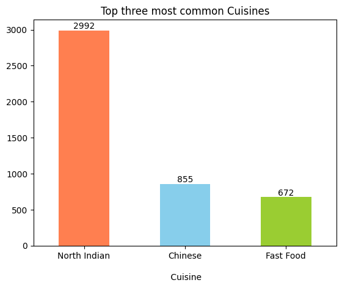

```python
ax = cuisines_df.plot(kind='bar', color=['coral', 'skyblue', 'yellowgreen'])
plt.title('Top three most common Cuisines')
plt.xticks(rotation=0)
plt.xlabel('\n Cuisine');

# Data labels
for i in ax.containers:
    ax.bar_label(i, label_type='edge')
```

North Indian, Chinese, and Fast Food are the most common Cuisines in this dataset

```python
# Calculate the percentage of restaurants that serve each of the top cuisines.
total_restaurants = len(df)
cuisines_by_restaurants = round((cuisines_df/total_restaurants)*100,2).head(3)
print('Percentage of restaurants that serve each of the top cuisines:\n' , cuisines_by_restaurants)
```

```
Percentage of restaurants that serve each of the top cuisines:
 Cuisines
North Indian    31.33
Chinese          8.95
Fast Food        7.04
Name: count, dtype: float64
```

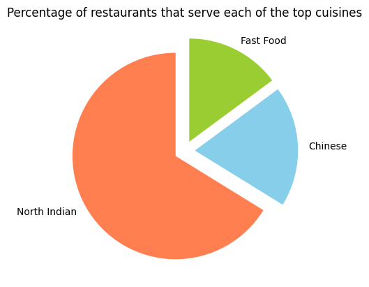

```python
ax = cuisines_by_restaurants.plot(kind='pie', colors=['coral', 'skyblue', 'yellowgreen'],
                                  explode=(0.1, 0.1, 0.1), startangle=90,
                                  radius=1)
plt.title('Percentage of restaurants that serve each of the top cuisines')
plt.ylabel('');
```

The percentage of restaurants serving North Indian is approximately 31% followed by Chinese and Fast food at 9% and 7% respectively.

### `Task-2: City Analysis`

- Identify the city with the highest number of restaurants in the dataset.
- Calculate the average rating for restaurants in each city.
- Determine the city with the highest average rating.

```python
# Identify the city with the highest number of restaurants in the dataset.
city_with_restaurants = df.City.value_counts()
city_with_restaurants
```

```
City
New Delhi           5473
Gurgaon             1118
Noida               1080
Faridabad            251
Ghaziabad             25
                    ...
Panchkula              1
Mc Millan              1
Mayfield               1
Macedon                1
Vineland Station       1
Name: count, Length: 141, dtype: int64
```

```python
max_restaurants_city = city_with_restaurants.idxmax()
max_restaurants_counts = city_with_restaurants.max()
print(f'The city which has maximum number of restaurants is {max_restaurants_city} with {max_restaurants_counts} restaurants')
```

```
The city which has maximum number of restaurants is New Delhi with 5473 restaurants
```

```python
# Calculate the average rating for restaurants in each city.
avg_rating = round(df.groupby('City')['Aggregate rating'].mean().sort_values(ascending=False), 1)
avg_rating
```

```
City
Inner City          4.9
Quezon City         4.8
Makati City         4.6
Pasig City          4.6
Mandaluyong City    4.6
                   ...
New Delhi           2.4
Montville           2.4
Mc Millan           2.4
Noida               2.0
Faridabad           1.9
Name: Aggregate rating, Length: 141, dtype: float64
```

```python
top_city_rating = avg_rating.head(10).sort_values(ascending=True)
```

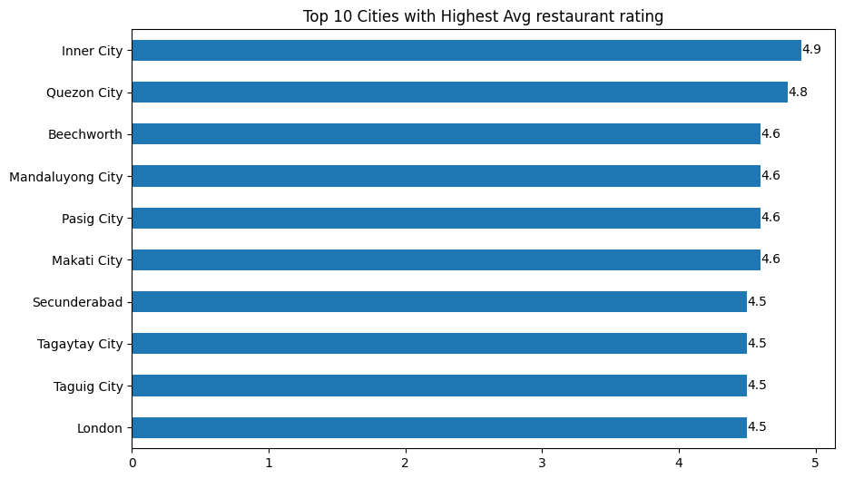

```python
plt.figure(figsize=(10,6))
ax= top_city_rating.plot(kind='barh')
plt.title('Top 10 Cities with Highest Avg restaurant rating')
plt.xlabel('')
plt.ylabel('');

for i in ax.containers:
    ax.bar_label(i, label_type='edge')
```

```python
# Determine the city with the highest average rating.
rating_top_city = top_city_rating.idxmax()
highest_rating = top_city_rating.max()
print(f"The city with the highest avg rating is {rating_top_city} with {highest_rating} rating")
```

```
The city with the highest avg rating is Inner City with 4.9 rating
```

### `Task-3: Price Range Distribution`

- Create a histogram or bar chart to visualize the distribution of price ranges among the restaurants.
- Calculate the percentage of restaurants in each price range category.

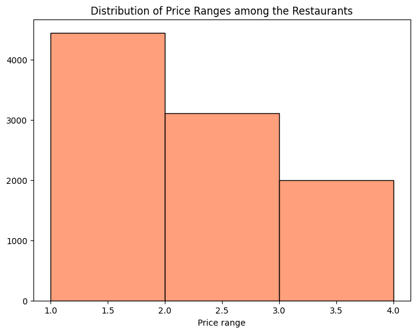

```python
# Create a histogram or bar chart to visualize the distribution of price ranges among the restaurants.
plt.figure(figsize=(8,6))
sns.histplot(x='Price range',
             data=df,
             bins=3,
            color='coral')
plt.ylabel('')
plt.title('Distribution of Price Ranges among the Restaurants');
```

```python
# Calculate the percentage of restaurants in each price range category.
restaurants_price_range = round(df['Price range'].value_counts(normalize=True)*100, 2)
restaurants_price_range
```

```
Price range
1    46.53
2    32.59
3    14.74
4     6.14
Name: proportion, dtype: float64
```

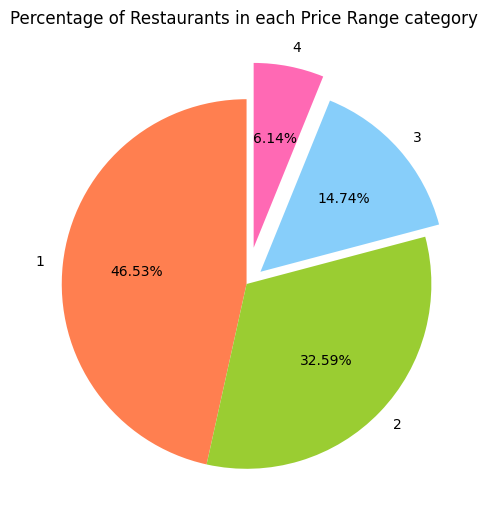

```python
plt.figure(figsize=(10, 6))
plt.pie(restaurants_price_range, labels=restaurants_price_range.index,
        autopct='%1.2f%%', explode=(0, 0, 0.1, 0.2),
        colors=['coral', 'yellowgreen', 'lightskyblue', 'hotpink'], startangle=90)
plt.ylabel('')
plt.title('Percentage of Restaurants in each Price Range category \n');
```

### `Task-4: Online Delivery`

- Determine the percentage of restaurants that offer online delivery.
- Compare the average ratings of restaurants with and without online delivery.

```python
# Determine the percentage of restaurants that offer online delivery.
restaurants_od = round(df['Has Online delivery'].value_counts(normalize=True)*100, 2)
print(restaurants_od)
print('25.66% of Restaurants offers Online Delivery')
```

```
Has Online delivery
No     74.34
Yes    25.66
Name: proportion, dtype: float64
25.66% of Restaurants offers Online Delivery
```

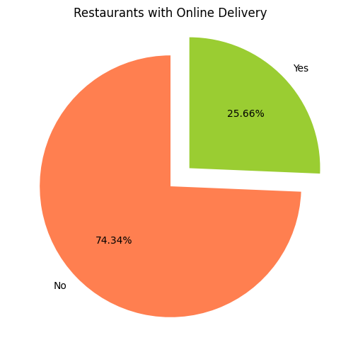

```python
# Visualization
plt.figure(figsize=(10, 6))
restaurants_od.plot(kind='pie', autopct='%1.2f%%', labels=restaurants_od.index,
                    colors=['coral', 'yellowgreen'], explode=(0, 0.2),
                    radius=1, startangle=90)
plt.title('Restaurants with Online Delivery')
plt.ylabel('');
```

```python
# Compare the average ratings of restaurants with and without online delivery.
avg_ratings_by_delivery = round(df.groupby('Has Online delivery')['Aggregate rating'].mean(), 1)
avg_ratings_by_delivery
```

```
Has Online delivery
No     2.5
Yes    3.2
Name: Aggregate rating, dtype: float64
```

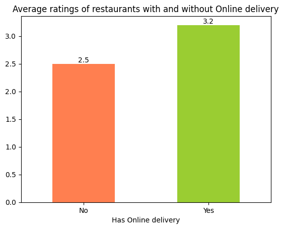

```python
ax = avg_ratings_by_delivery.plot(kind='bar', color=['coral', 'yellowgreen'])
plt.title('Average ratings of restaurants with and without Online delivery')
plt.xticks(rotation=0)

for i in ax.containers:
    ax.bar_label(i, label_type='edge')
```